# Intro to TensorFlow

```python
import numpy as np
import tensorflow as tf
```

## TensorFlow requires explicit evaluation!

```python
a = np.zeros((2,2))
ta = tf.zeros((2,2))
```

```python
print(a)
```

```
[[ 0.  0.]
 [ 0.  0.]]
```

```python
print(ta)
```

```
Tensor("zeros:0", shape=(2, 2), dtype=float32)
```

```python
tf.InteractiveSession()
print(ta.eval())
```

```
[[ 0.  0.]
 [ 0.  0.]]
```

## TensorFlow Session Object

- "A Session obeject encapsulates the environment in which Tensor objects are evaluated"
- tf.InteractiveSession() is just convenient syntactic sugar for keeping a default session open in ipython.
- sess.run(c) is an example of a TensorFlow *Fetch*. Will say more on this soon.

```python
a = tf.constant(5.0)
b = tf.constant(6.0)
c = a * b
```

```python
with tf.Session() as sess:
    print(sess.run(c))  # c.eval() ia just syntactic sugar for sess.run(c) in the currently active session!
    print(c.eval())
```

```
30.0
30.0
```

## Tensorflow Computation Graph

- "TensorFlow programs are usually structured into a construction phase, that assembles a graoh, and an execution phase taht uses a session to execute ops in the graph."
- All computations add nodes to global default graph. Such like "c=a*b" in the above block.

## TensorFlow Variables

- "When you train a model you use variables to hold and update parameters. Variables are in-memory buffers containing tensors"
- All tensors we've used previously have been constant tensors, not variables.
- TensorFlow variables must be initialized before they have values!Contrast witg constant tensors.

```python
W1 = tf.ones((2,2))
W2 = tf.Variable(tf.zeros((2,2)), name="weights")
with tf.Session() as sess:
    print(sess.run(W1))
    #sess.run(tf.initialize_all_variables())
    sess.run(tf.global_variables_initializer()) # Note the initialization step
    print(sess.run(W2))
```

```
[[ 1.  1.]
 [ 1.  1.]]
[[ 0.  0.]
 [ 0.  0.]]
```

```python
# variable objects can be initialized from constants or random values
W = tf.Variable(tf.zeros((2,2)), name="weights")
R = tf.Variable(tf.random_normal((2,2)), name = "random_weights")
with tf.Session() as sess:
    sess.run(tf.global_variables_initializer())
    print(sess.run(W))
    print(sess.run(R))
```

```
[[ 0.  0.]
 [ 0.  0.]]
[[-1.1971699  -0.16260433]
 [-0.1181782  -0.87105316]]
```

### Updating Variable State

```python
state = tf.Variable(0, name="counter")
new_value = tf.add(state, tf.constant(1))  # Roughly "new_value = state + 1"
update = tf.assign(state, new_value)       # Roughly "state = new_value"

with tf.Session() as sess:
    sess.run(tf.global_variables_initializer())
    print(sess.run(state))
    for _ in range(3):
        sess.run(update)                   # Roughly "state = state + 1"
        print(sess.run(state))
```

```
0
1
2
3
```

### Fetching Variables State

```python
input1 = tf.constant(3.0)
input2 = tf.constant(2.0)
input3 = tf.constant(5.0)
intermed = tf.add(input2, input3)
mul = tf.multiply(input1, intermed)

with tf.Session() as sess:
    result = sess.run([mul, intermed])
    print(result)
```

```
[21.0, 7.0]
```

### Inputting Data

- Manually defined tensors
- Inputting data with tf.convert_to_tensro() isconvenient, but doesn't scale.
- Use tf.placeholder variables(dummy nodes that provide entry points for data to computational graph).
- A feed_dict is a python dictionary mapping from tf.placeholder vars(or their names) to data (numpy arrays, lists, etc.).

```python
a = np.zeros((3,3))
ta = tf.convert_to_tensor(a)
with tf.Session() as sess:
    print(sess.run(ta))
```

```
[[ 0.  0.  0.]
 [ 0.  0.  0.]
 [ 0.  0.  0.]]
```

```python
input1 = tf.placeholder(tf.float32)
input2 = tf.placeholder(tf.float32)
output = tf.multiply(input1, input2)

with tf.Session() as sess:
    print(sess.run([output], feed_dict={input1:[7.], input2:[2.]}))
```

```
[array([ 14.], dtype=float32)]
```

## Variable Scope

- Complicated TensorFlow models can have hundreds of variables.
  - `tf.variable_scope()` provides simple name-spacing to avoid clashed.
  - `tf.get_variable()` creates/accesses variables from within a variable scope.
- Variable scope is a simple type of namespacing that adds prefixes to variable names within scope
- Variable scopes control variable (re)use

```python
with tf.variable_scope("foo"):
    with tf.variable_scope("bar"):
        v = tf.get_variable("v", [1])
assert v.name == "foo/bar/v:0"
```

```python
with tf.variable_scope("foo2"):
    v = tf.get_variable("v", [1])   #default setting: reuse=False
    tf.get_variable_scope().reuse_variables()
    v1 = tf.get_variable("v", [1])
assert v1 == v
```

### Understanding get_variable

- Behavior depends on whether variable reuse enables
- case 1: resuse set to false
  - Create and return new variable
- case 2: resues
  - Search for existingg variable with given name. Raise **ValueError** if none found.

```python
with tf.variable_scope("foo3"):
    v = tf.get_variable("v", [1])
assert v.name == "foo3/v:0"
```

```python
with tf.variable_scope("foo4"):
    v = tf.get_variable("v", [1])
with tf.variable_scope("foo4", reuse=True):
    v1 = tf.get_variable("v", [1])
assert v1 == v
```

# EX: Linear Regression in TensorFlow

```python
import numpy as np
import matplotlib.pyplot as plt
import seaborn
%matplotlib inline
```

```python
# Define input data
X_data = np.arange(100, step=.1)
y_data = X_data + 20 * np.sin(X_data/10)
```

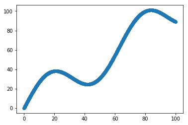

```python
# Plot input data
plt.scatter(X_data, y_data)
```

```python
# Define data size and batch size
n_samples = 1000
batch_size = 100
```

```python
# Tensorflow is finicky about shapes, so resize
X_data = np.reshape(X_data, (n_samples,1))
y_data = np.reshape(y_data, (n_samples,1))
```

```python
# Define placeholders for input
X = tf.placeholder(tf.float32, shape=(batch_size, 1))
y = tf.placeholder(tf.float32, shape=(batch_size, 1))
```

```python
# Define variables to be learned
with tf.variable_scope("linear-regression"):
    W = tf.get_variable("weights", (1,1),
                       initializer = tf.random_normal_initializer())
    b = tf.get_variable("bias", (1,),
                       initializer = tf.constant_initializer(0.0))
    y_pred = tf.matmul(X, W) + b
    loss = tf.reduce_sum((y-y_pred)**2/n_samples)
```

```python
# Sample code to run one step of gradient descent:
opt = tf.train.AdamOptimizer()
opt_operation = opt.minimize(loss)   # Note TensorFlow scope is not python scope! Python variable loss os still visible

with tf.Session() as sess:
    sess.run(tf.global_variables_initializer())
    sess.run([opt_operation], feed_dict={X: X_data, y:y_data})
```

```python
# Sample code to run full gradient descent:
# Define optimizer operation
opt_operation = tf.train.AdamOptimizer().minimize(loss)

with tf.Session() as sess:
    # Initialize Variables in graph
    sess.run(tf.global_variables_initializer())
    #Gradient descent loop for 500 steps
    for _ in range(500):
        # Select random minibatch
        indices = np.random.choice(n_samples, batch_size)
        X_batch, y_batch = X_data[indices], y_data[indices]
        # Do gradient descent step
        _, loss_val = sess.run([opt_operation, loss], feed_dict={X: X_batch, y: y_batch})
```

## TensorFlow Gradient Computation

- TensorFlow nodes in computation graph have attached gradient operations.
- Use backpropagation (using node-specific gradient ops) to compute required gradients for all variables in graph.

## TensorFlow Gotchas/Debugging

- Convert tensors to numpy aray and print.
- TensorFlow is fastidious about types and shapes. Check that types/shapes of all tensors match.
- TensorFlow API is less mature than Numpy API. Many advanced Numpy operations(e.g. complicated array slicing) not supported yet!
- If you're stuck,
  - try making a pure Numpy implementation of forward computation.
  - Then look for analog of each Numpy function in TensorFlow API.
  - Use tf.InteractiveSession() tp experiment in shell. Trial and error works!

## TensorBoard

- built-in visualization tools.
- Tricky to set up when TensorFlow is running remotely.